# Non-linear regression on AirBnb dataset

Author

Xiaojing Ni Group 15

```r
library(caret)
library(dplyr)
library(tidyr)
library(rpart)
library(glmnet)
library(rattle)
library(ggplot2)
library(stringr)
library(reshape2)
library(tidyverse)
library(visNetwork)
```

```r
## read data

airbnb <- read.csv("../data/Aemf1.csv")
str(airbnb)
```

```
'data.frame':   41714 obs. of  19 variables:
 $ City                       : chr  "Amsterdam" "Amsterdam" "Amsterdam" "Amsterdam" ...
 $ Price                      : num  194 344 264 434 486 ...
 $ Day                        : chr  "Weekday" "Weekday" "Weekday" "Weekday" ...
 $ Room.Type                  : chr  "Private room" "Private room" "Private room" "Private room" ...
 $ Shared.Room                : chr  "False" "False" "False" "False" ...
 $ Private.Room               : chr  "True" "True" "True" "True" ...
 $ Person.Capacity            : num  2 4 2 4 2 3 2 4 4 2 ...
 $ Superhost                  : chr  "False" "False" "False" "False" ...
 $ Multiple.Rooms             : int  1 0 0 0 0 0 0 0 0 1 ...
 $ Business                   : int  0 0 1 1 0 0 0 0 0 0 ...
 $ Cleanliness.Rating         : num  10 8 9 9 10 8 10 10 9 10 ...
 $ Guest.Satisfaction         : num  93 85 87 90 98 100 94 100 96 88 ...
 $ Bedrooms                   : int  1 1 1 2 1 2 1 3 2 1 ...
 $ City.Center..km.           : num  5.023 0.488 5.748 0.385 0.545 ...
 $ Metro.Distance..km.        : num  2.539 0.239 3.652 0.44 0.319 ...
 $ Attraction.Index           : num  78.7 631.2 75.3 493.3 552.8 ...
 $ Normalised.Attraction.Index: num  4.17 33.42 3.99 26.12 29.27 ...
 $ Restraunt.Index            : num  98.3 837.3 95.4 875 815.3 ...
 $ Normalised.Restraunt.Index : num  6.85 58.34 6.65 60.97 56.81 ...
```

```r
airbnb$City <- factor(airbnb$City)
airbnb$Day <- factor(airbnb$Day)
airbnb$Room.Type <- factor(airbnb$Room.Type)
airbnb$Shared.Room <- factor(airbnb$Shared.Room)
airbnb$Private.Room  <- factor(airbnb$Private.Room )
airbnb$Superhost  <- factor(airbnb$Superhost )
airbnb$Multiple.Rooms  <- factor(airbnb$Multiple.Rooms )
airbnb$Business  <- factor(airbnb$Business )
airbnb$Business  <- factor(airbnb$Business )

str(airbnb)
```

```
'data.frame':   41714 obs. of  19 variables:
 $ City                       : Factor w/ 9 levels "Amsterdam","Athens",..: 1 1 1 1 1 1 1 1 1 1 ...
 $ Price                      : num  194 344 264 434 486 ...
 $ Day                        : Factor w/ 2 levels "Weekday","Weekend": 1 1 1 1 1 1 1 1 1 1 ...
 $ Room.Type                  : Factor w/ 3 levels "Entire home/apt",..: 2 2 2 2 2 2 2 1 1 2 ...
 $ Shared.Room                : Factor w/ 2 levels "False","True": 1 1 1 1 1 1 1 1 1 1 ...
 $ Private.Room               : Factor w/ 2 levels "False","True": 2 2 2 2 2 2 2 1 1 2 ...
 $ Person.Capacity            : num  2 4 2 4 2 3 2 4 4 2 ...
 $ Superhost                  : Factor w/ 2 levels "False","True": 1 1 1 1 2 1 1 2 1 1 ...
 $ Multiple.Rooms             : Factor w/ 2 levels "0","1": 2 1 1 1 1 1 1 1 1 2 ...
 $ Business                   : Factor w/ 2 levels "0","1": 1 1 2 2 1 1 1 1 1 1 ...
 $ Cleanliness.Rating         : num  10 8 9 9 10 8 10 10 9 10 ...
 $ Guest.Satisfaction         : num  93 85 87 90 98 100 94 100 96 88 ...
 $ Bedrooms                   : int  1 1 1 2 1 2 1 3 2 1 ...
 $ City.Center..km.           : num  5.023 0.488 5.748 0.385 0.545 ...
 $ Metro.Distance..km.        : num  2.539 0.239 3.652 0.44 0.319 ...
 $ Attraction.Index           : num  78.7 631.2 75.3 493.3 552.8 ...
 $ Normalised.Attraction.Index: num  4.17 33.42 3.99 26.12 29.27 ...
 $ Restraunt.Index            : num  98.3 837.3 95.4 875 815.3 ...
 $ Normalised.Restraunt.Index : num  6.85 58.34 6.65 60.97 56.81 ...
```

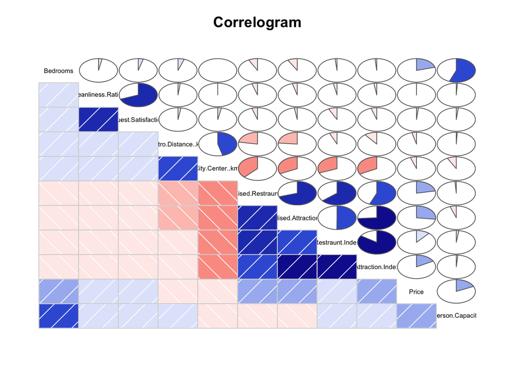

```r
library(corrgram)
nums <- unlist(lapply(airbnb, is.numeric), use.names = FALSE)
air_num <- airbnb[ , nums]



corrgram(airbnb,
         order = TRUE,              # If TRUE, PCA-based re-ordering
         upper.panel = panel.pie,   # Panel function above diagonal
         lower.panel = panel.shade, # Panel function below diagonal
         text.panel = panel.txt,    # Panel function of the diagonal
         main = "Correlogram")
```

### 0.1 Feature selection

Price has higher correlation with attraction.index, and restaruant index, and bedroom. These thee using polynomial term, and others are linear term.

Discrete variables: bedroom, person capacity… polynomial may not suitble.

### 0.2 Training, testing, validation spliting

```r
set.seed(51215)

## generate 1-3 as the group of training, testing, and validation set
idx <- sample(seq(1, 3), size = nrow(airbnb), replace = TRUE, prob = c(.75, .15, .15))
train <- airbnb[idx == 1,]
dev <- airbnb[idx == 2,]
test <- airbnb[idx == 3,]

dim(train);dim(dev);dim(test)
```

```
[1] 29672    19
```

```
[1] 6015   19
```

```
[1] 6027   19
```

```r
test1 <- rbind(dev,test)
```

```r
## save the datasets
# write.csv(train, "../data/train.csv")
# write.csv(dev, "../data/dev.csv")
# write.csv(test, "../data/test.csv")
```

Remove duplicate column,Shared.Room and Private.Room (redundant, Room.Type has three levels including these two)

```r
airbnb <- airbnb[,!names(airbnb) %in% c("Shared.Room","Private.Room")]
set.seed(51215)

## generate 1-3 as the group of training, testing, and validation set
idx <- sample(seq(1, 3), size = nrow(airbnb), replace = TRUE, prob = c(.75, .15, .15))
train <- airbnb[idx == 1,]
dev <- airbnb[idx == 2,]
test <- airbnb[idx == 3,]

dim(train);dim(dev);dim(test)
```

```
[1] 29672    17
```

```
[1] 6015   17
```

```
[1] 6027   17
```

### 0.3 Examine relationship between y and x

Price is a highly skewed distribution. Log price has better distribution, thus, log price is used for modeling. Continues features are also logged.

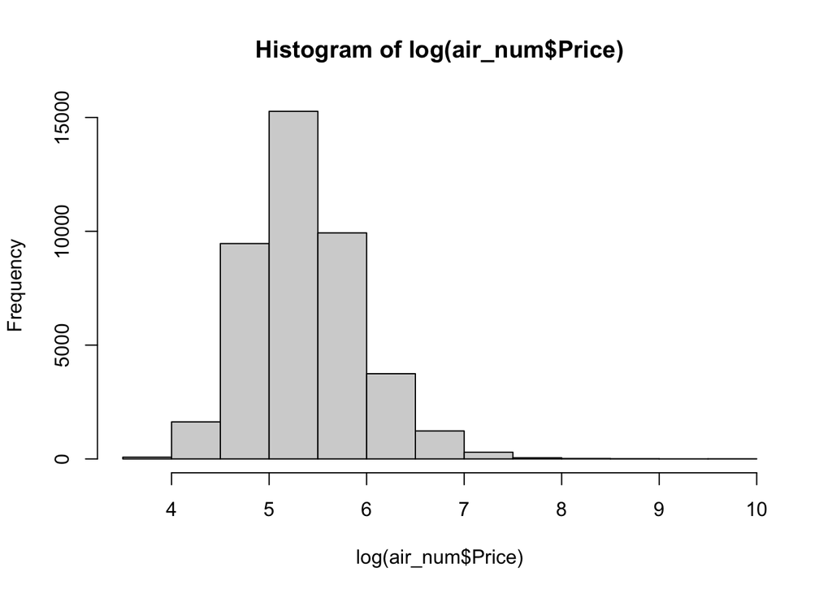

```r
hist(log(air_num$Price))
```

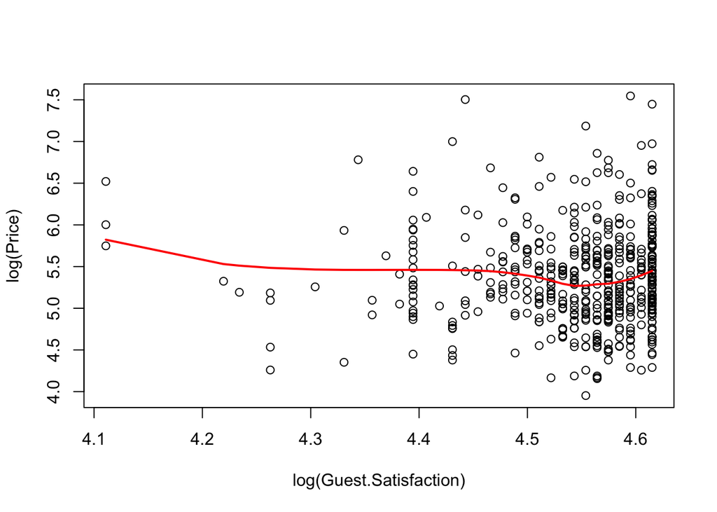

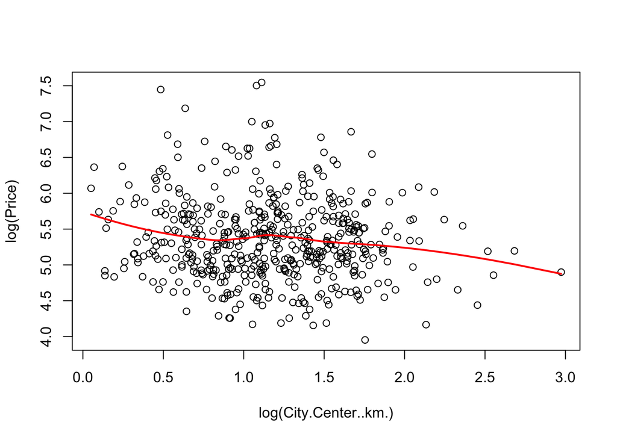

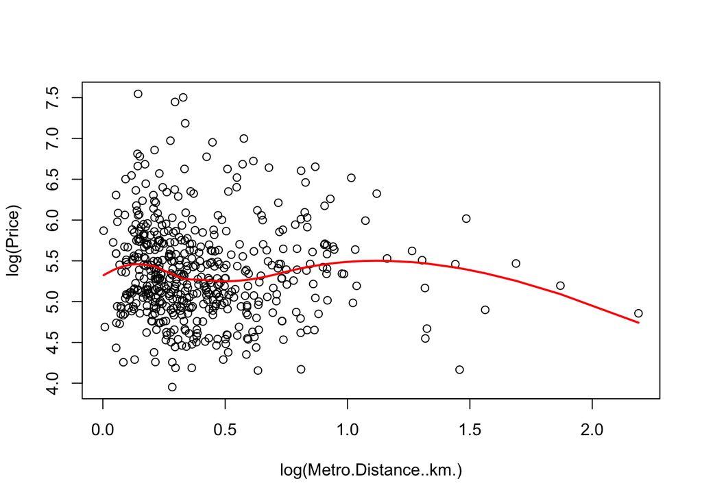

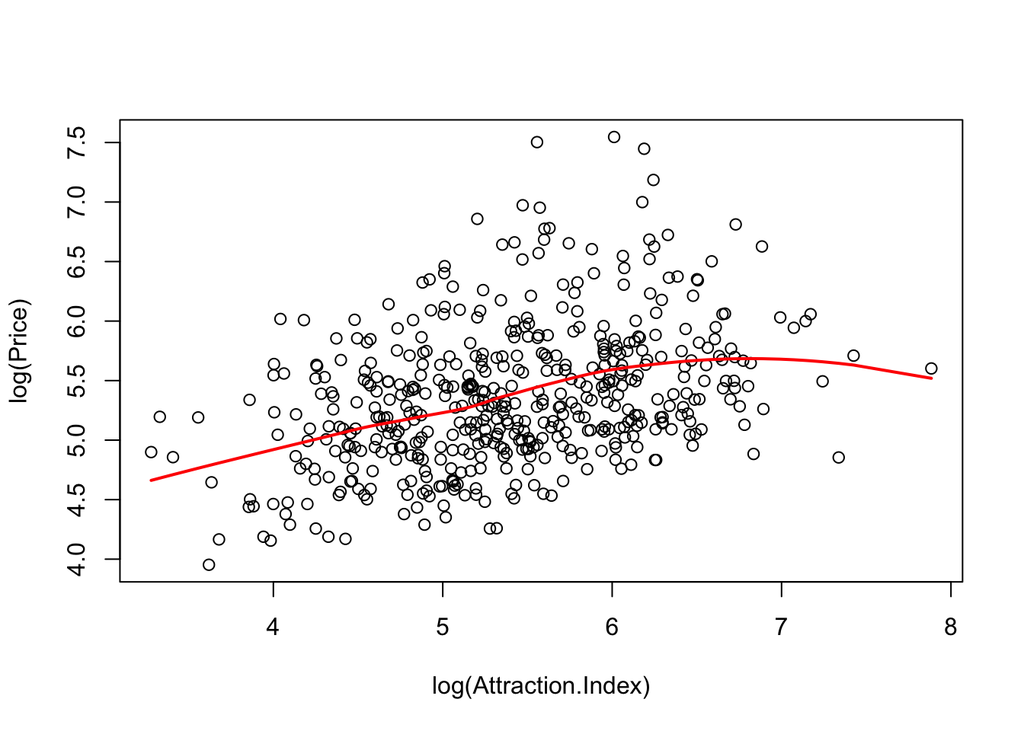

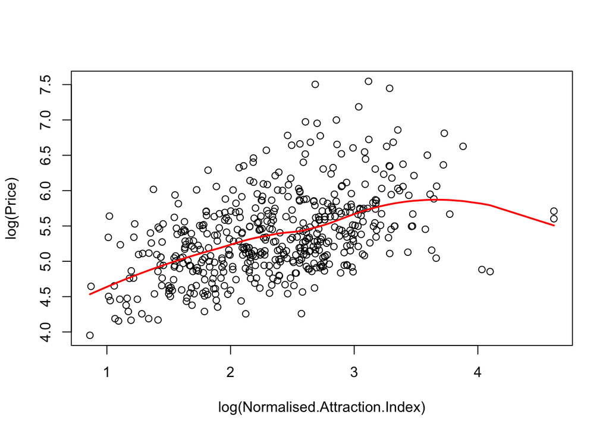

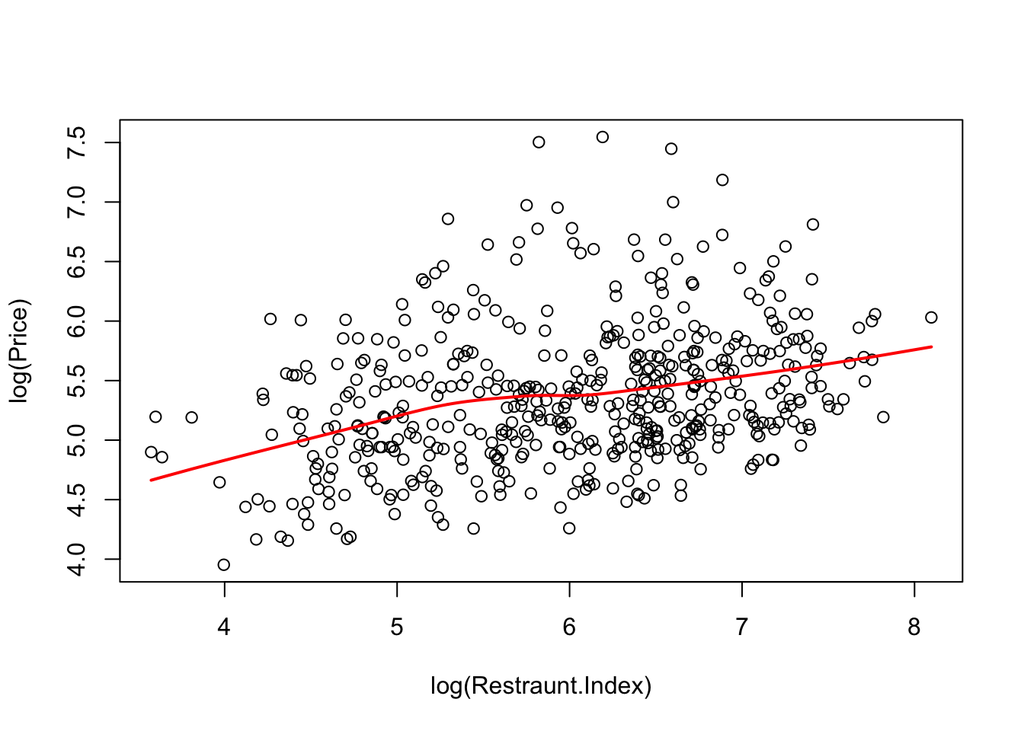

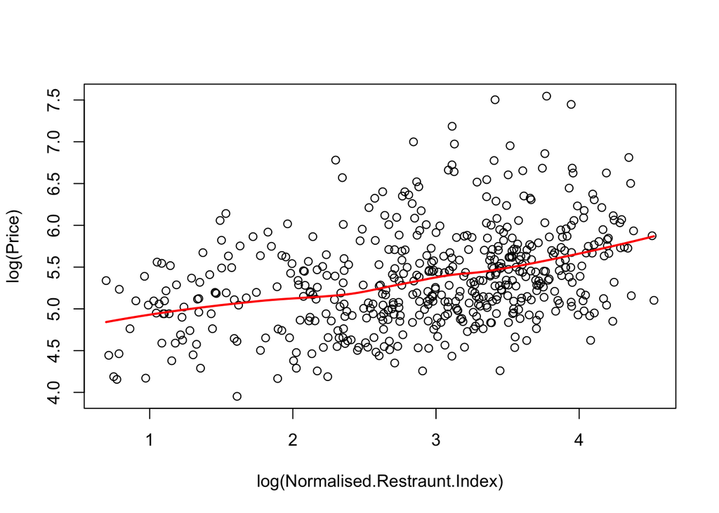

```r
idx <- sample(nrow(air_num), 500, replace = F)

### log x
for (i in c(4,6,7,8,9,10,11)){
    y = log(air_num[["Price"]]+1)[idx]
    x = log(air_num[[i]]+1)[idx]
    order_x <- order(x)
    y <- y[order_x]
    x <- x[order_x]
    lo <- loess(y~x)
    plot(x = x,y = y,xlab=paste0("log(",colnames(air_num)[i],")"), ylab="log(Price)")
    lines(x = x, y = predict(lo), col='red', lwd=2)
}
```

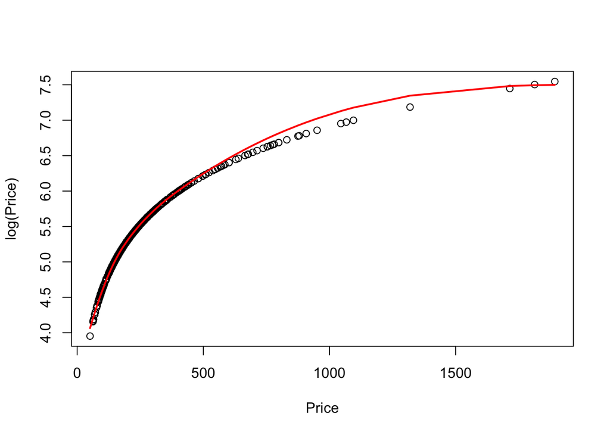

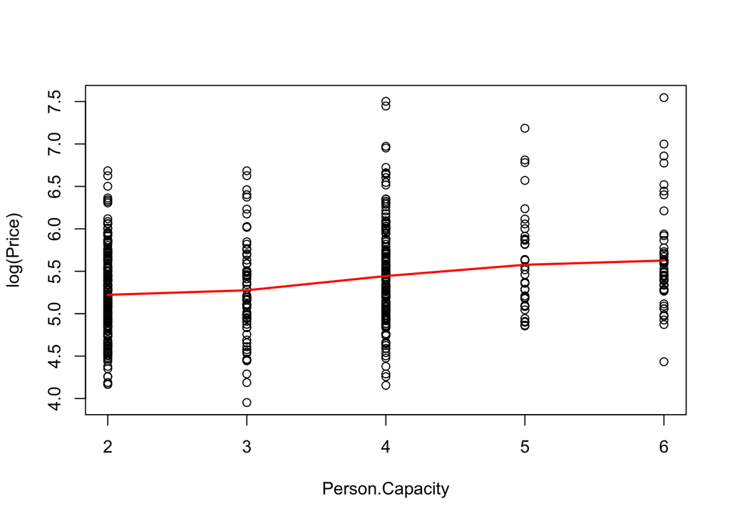

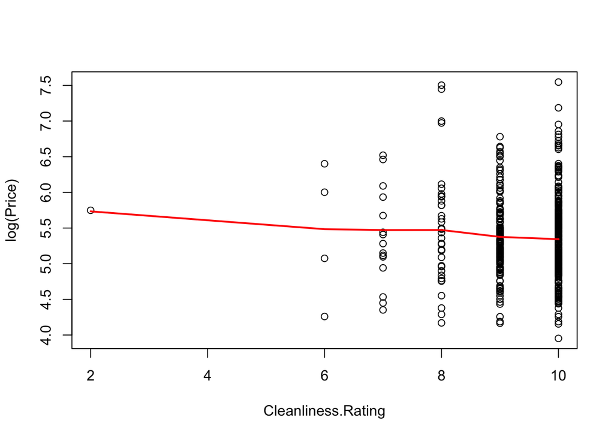

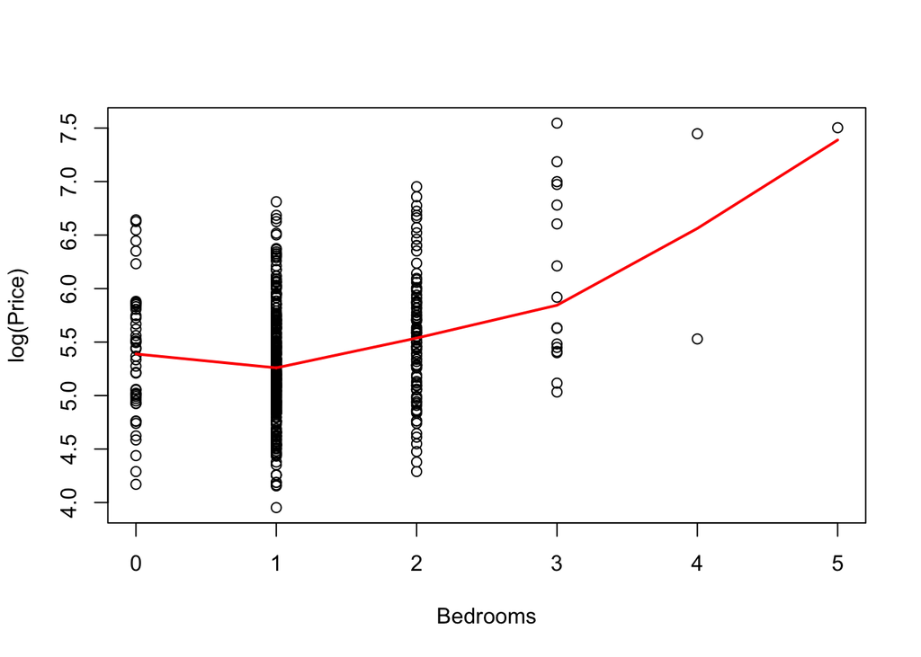

```r
### original x
for (i in c(1,2,3,5)){
    y = log(air_num[["Price"]]+1)[idx]
    x = air_num[[i]][idx]
    order_x <- order(x)
    y <- y[order_x]
    x <- x[order_x]
    lo <- loess(y~x)
    plot(x = x,y = y,xlab=colnames(air_num)[i], ylab="log(Price)")
    lines(x = x, y = predict(lo), col='red', lwd=2)
}
```

### 0.4 Polynomial model with lasso regularization, using CV tuning lambda

Polynomial only works on numeric features. Based on the distribution plots above,

- log Guest.Satisfaction can be a linear
- log City.Center..km. can be a poly 3
- log Metro.Distance..km. can be a poly 3
- log Normalised.Attraction.Index can be a poly 4
- log Normalised.Restraunt.Index can be a poly 3
- Person.Capacity can be a poly 2 or a linear
- Cleanliness.Rating can be a poly 2 or a linear
- Bedrooms can be a poly 2

Thus, the model is constructed as below.

```r
model_nonlinear <-
    lm(
        log(Price) ~ poly(Bedrooms, 2) +
            poly(Cleanliness.Rating) +
            Person.Capacity +
            poly(log(Normalised.Restraunt.Index), 3)+
            poly(log(Normalised.Attraction.Index), 4) + poly(log(`Metro.Distance..km.`), 3) +
            poly(log(`City.Center..km.`), 3) +
            log(Guest.Satisfaction) +
            City + Day + Superhost, data=train)

summary(model_nonlinear)
```

```
Call:
lm(formula = log(Price) ~ poly(Bedrooms, 2) + poly(Cleanliness.Rating) +
    Person.Capacity + poly(log(Normalised.Restraunt.Index), 3) +
    poly(log(Normalised.Attraction.Index), 4) + poly(log(Metro.Distance..km.),
    3) + poly(log(City.Center..km.), 3) + log(Guest.Satisfaction) +
    City + Day + Superhost, data = train)

Residuals:
    Min      1Q  Median      3Q     Max
-2.1103 -0.2330 -0.0231  0.2029  5.1480

Coefficients:
                                            Estimate Std. Error t value
(Intercept)                                 6.109712   0.111498  54.796
poly(Bedrooms, 2)1                         12.140571   0.443619  27.367
poly(Bedrooms, 2)2                          1.575657   0.361772   4.355
poly(Cleanliness.Rating)                    8.235481   0.492779  16.712
Person.Capacity                             0.141738   0.002025  69.984
poly(log(Normalised.Restraunt.Index), 3)1  10.703530   1.050499  10.189
poly(log(Normalised.Restraunt.Index), 3)2   1.099345   0.481970   2.281
poly(log(Normalised.Restraunt.Index), 3)3   1.746303   0.407393   4.287
poly(log(Normalised.Attraction.Index), 4)1 32.774706   0.896394  36.563
poly(log(Normalised.Attraction.Index), 4)2  3.776198   0.425386   8.877
poly(log(Normalised.Attraction.Index), 4)3 -1.847868   0.394440  -4.685
poly(log(Normalised.Attraction.Index), 4)4 -2.716966   0.371838  -7.307
poly(log(Metro.Distance..km.), 3)1          2.972304   0.436532   6.809
poly(log(Metro.Distance..km.), 3)2          1.173615   0.384407   3.053
poly(log(Metro.Distance..km.), 3)3          0.830769   0.379847   2.187
poly(log(City.Center..km.), 3)1             4.199248   0.667676   6.289
poly(log(City.Center..km.), 3)2            -0.215850   0.417650  -0.517
poly(log(City.Center..km.), 3)3            -0.139236   0.379455  -0.367
log(Guest.Satisfaction)                    -0.095075   0.024456  -3.888
CityAthens                                 -1.100225   0.014046 -78.330
CityBarcelona                              -0.696851   0.012974 -53.711
CityBerlin                                 -0.920145   0.014086 -65.322
CityBudapest                               -1.193973   0.012269 -97.313
CityLisbon                                 -0.701974   0.012594 -55.739
CityParis                                  -0.493227   0.012514 -39.415
CityRome                                   -0.971131   0.010756 -90.290
CityVienna                                 -0.655051   0.015844 -41.343
```

[output cut: 23 more lines]

```
CityBarcelona                               < 2e-16 ***
CityBerlin                                  < 2e-16 ***
CityBudapest                                < 2e-16 ***
CityLisbon                                  < 2e-16 ***
CityParis                                   < 2e-16 ***
CityRome                                    < 2e-16 ***
CityVienna                                  < 2e-16 ***
DayWeekend                                  < 2e-16 ***
SuperhostTrue                              0.001200 **
---
Signif. codes:  0 '***' 0.001 '**' 0.01 '*' 0.05 '.' 0.1 ' ' 1

Residual standard error: 0.3586 on 29643 degrees of freedom
Multiple R-squared:  0.603, Adjusted R-squared:  0.6027
F-statistic:  1608 on 28 and 29643 DF,  p-value: < 2.2e-16
```

With lasso regularization

```r
# empty list
train_list <- vector(mode='list', length=9)

train_list[[1]] <- matrix(poly(train$Bedrooms, 2), ncol = 2, byrow = F)
colnames(train_list[[1]]) <- c("Bedrooms1", "Bedrooms2")

train_list[[2]] <- matrix(train$Cleanliness.Rating, ncol = 1)
colnames(train_list[[2]]) <- c("Cleanliness.Rating")

train_list[[3]] <- matrix(train$Person.Capacity, ncol = 1)
colnames(train_list[[3]]) <- c("Person.Capacity")

train_list[[4]] <- matrix(poly(log(train$Normalised.Restraunt.Index), 3),
                          ncol = 3, byrow = F)
colnames(train_list[[4]]) <- paste("log(Normalised.Restraunt.Index)",
                                   seq.int(3), sep = "")

train_list[[5]] <- matrix(poly(log(train$Normalised.Attraction.Index), 4),
                          ncol = 4, byrow = F)
colnames(train_list[[5]]) <- paste("log(Normalised.Attraction.Index)",
                                   seq.int(4), sep = "")

train_list[[6]] <- matrix(poly(log(train$`Metro.Distance..km.`), 3),
                          ncol = 3, byrow = F)
colnames(train_list[[6]]) <- paste("log(Metro.Distance..km.)",
                                   seq.int(3), sep = "")

train_list[[7]] <- matrix(poly(log(train$`City.Center..km.`), 3),
                          ncol = 3, byrow = F)
colnames(train_list[[7]]) <- paste("log(City.Center..km.)",
                                   seq.int(3), sep = "")

train_list[[8]] <- matrix(log(train$Guest.Satisfaction), ncol = 1)
colnames(train_list[[8]]) <- c("log(Guest.Satisfaction)")

train_list[[9]] <- model.matrix(~ Day + City + Superhost, data = train)
train_list[[9]] <- train_list[[9]][,-1] ## remove Intercept

## sanity check
lapply(train_list, dim)
```

```
[[1]]
[1] 29672     2

[[2]]
[1] 29672     1

[[3]]
[1] 29672     1

[[4]]
[1] 29672     3

[[5]]
[1] 29672     4

[[6]]
[1] 29672     3

[[7]]
[1] 29672     3

[[8]]
[1] 29672     1

[[9]]
[1] 29672    10
```

```r
cv_lasso_x <- do.call("cbind", train_list)
```

```r
cv_lasso_y <- as.vector(log(train$Price))

## model, 10 fold cv on alpha
cv_lasso <- cv.glmnet(y = cv_lasso_y,
                      x = cv_lasso_x,
                      alpha = 1, # 1 is lasso regression
                      standardize = TRUE,
                      nfolds = 10,
                      thresh = 1e-12)

## prediction
pred <- predict(cv_lasso, s = cv_lasso$lambda.1se, newx = cv_lasso_x)

##1se, best (note: cv best point is not the minium)
cv_lasso$lambda.1se
```

```
[1] 0.004136051
```

```r
##rms
(rms_cv_10 <- cv_lasso$cvm[which(cv_lasso$lambda==cv_lasso$lambda.1se)])
```

```
[1] 0.1315213
```

```r
## CV sd
(mean(cv_lasso$cvsd))
```

```
[1] 0.003705928
```

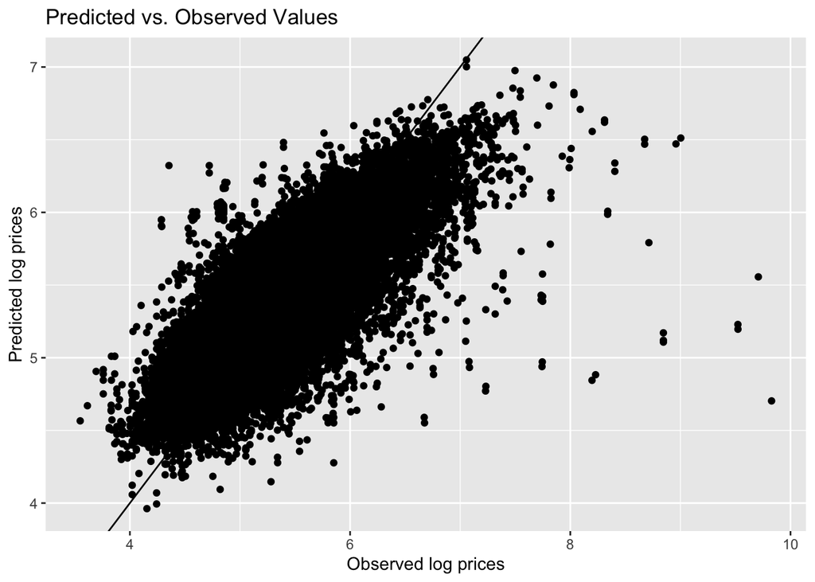

```r
## plot
train$yhat_lasso <- as.vector(pred)
train$logy <- log(train$Price)
ggplot(train, aes(x=logy, y= yhat_lasso)) +
  geom_point() +
  geom_abline(intercept=0, slope=1) +
  labs(x='Observed log prices', y='Predicted log prices', title='Predicted vs. Observed Values')
```

### 0.5 Training MSE for log price

```r
mean((train$logy - train$yhat_lasso)^2)
```

```
[1] 0.1312015
```

### 0.6 cv rms

```r
##rms
(rms_cv_10 <- cv_lasso$cvm[which(cv_lasso$lambda==cv_lasso$lambda.1se)])
```

```
[1] 0.1315213
```

### 0.7 CV sd

```r
## CV sd
(mean(cv_lasso$cvsd))
```

```
[1] 0.003705928
```

For regularization, I choose Lasso regression with full features. In this way, some of the feature will have coefficient of zero, making the model simplier.

### 0.8 Test error

```r
# empty list
test_list <- vector(mode='list', length=9)

test_list[[1]] <- matrix(poly(test1$Bedrooms, 2), ncol = 2, byrow = F)
colnames(test_list[[1]]) <- c("Bedrooms1", "Bedrooms2")

test_list[[2]] <- matrix(test1$Cleanliness.Rating, ncol = 1)
colnames(test_list[[2]]) <- c("Cleanliness.Rating")

test_list[[3]] <- matrix(test1$Person.Capacity, ncol = 1)
colnames(test_list[[3]]) <- c("Person.Capacity")

test_list[[4]] <- matrix(poly(log(test1$Normalised.Restraunt.Index), 3),
                          ncol = 3, byrow = F)
colnames(test_list[[4]]) <- paste("log(Normalised.Restraunt.Index)",
                                   seq.int(3), sep = "")

test_list[[5]] <- matrix(poly(log(test1$Normalised.Attraction.Index), 4),
                          ncol = 4, byrow = F)
colnames(test_list[[5]]) <- paste("log(Normalised.Attraction.Index)",
                                   seq.int(4), sep = "")

test_list[[6]] <- matrix(poly(log(test1$`Metro.Distance..km.`), 3),
                          ncol = 3, byrow = F)
colnames(test_list[[6]]) <- paste("log(Metro.Distance..km.)",
                                   seq.int(3), sep = "")

test_list[[7]] <- matrix(poly(log(test1$`City.Center..km.`), 3),
                          ncol = 3, byrow = F)
colnames(test_list[[7]]) <- paste("log(City.Center..km.)",
                                   seq.int(3), sep = "")

test_list[[8]] <- matrix(log(test1$Guest.Satisfaction), ncol = 1)
colnames(test_list[[8]]) <- c("log(Guest.Satisfaction)")

test_list[[9]] <- model.matrix(~ Day + City + Superhost, data = test1)
test_list[[9]] <- test_list[[9]][,-1] ## remove Intercept

## sanity check
lapply(test_list, dim)
```

```
[[1]]
[1] 12042     2

[[2]]
[1] 12042     1

[[3]]
[1] 12042     1

[[4]]
[1] 12042     3

[[5]]
[1] 12042     4

[[6]]
[1] 12042     3

[[7]]
[1] 12042     3

[[8]]
[1] 12042     1

[[9]]
[1] 12042    10
```

```r
test_x <- do.call("cbind", test_list)
```

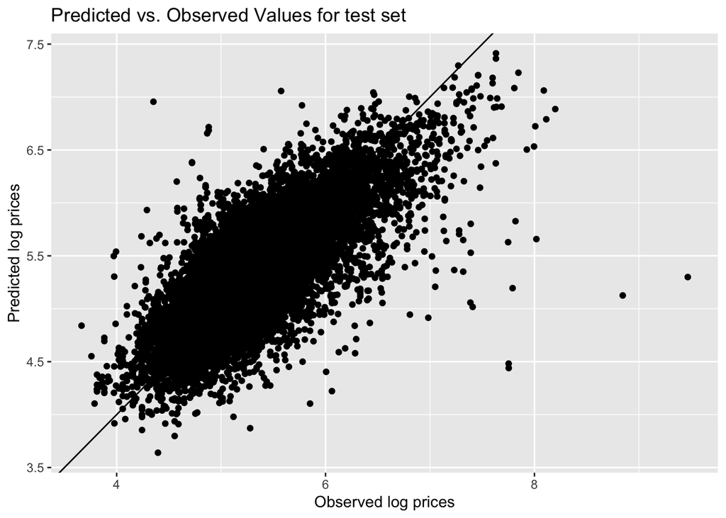

```r
cv_lasso_y <- as.vector(log(test1$Price))

## prediction
pred_test <- predict(cv_lasso, s = cv_lasso$lambda.1se, newx = test_x)

## plot
test1$yhat_lasso <- as.vector(pred_test)
test1$logy <- log(test1$Price)
ggplot(test1, aes(x=logy, y= yhat_lasso)) +
  geom_point() +
  geom_abline(intercept=0, slope=1) +
  labs(x='Observed log prices', y='Predicted log prices', title='Predicted vs. Observed Values for test set')
```

```r
## MSE

mean((test1$logy - test1$yhat_lasso)^2)
```

```
[1] 0.145796
```